# Solving Real World Issues With RCzechia

## Terrain of the Czech Republic

Understanding the lay of the land is important in many use cases in physical sciences; one of them is interpreting the flow of rivers.

Visualizing the slope & height of terrain is an important first step in understanding it.

Package RCzechia supports two versions of relief visualization:

- actual elevation model (meters above sea level)
- shaded relief

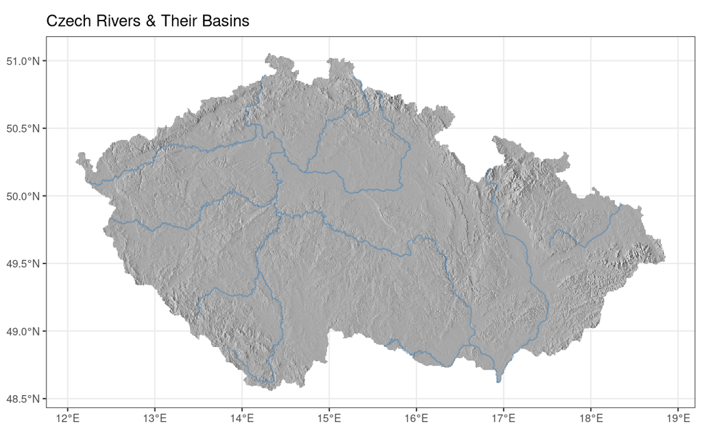

```r
library(RCzechia)
library(ggplot2)
library(terra)
library(tidyterra)
library(dplyr)

# terrain cropped to "Czechia proper"
relief <- vyskopis("rayshaded", cropped = TRUE)

# report results
ggplot() +
  tidyterra::geom_spatraster(data = relief) +
  scale_fill_gradientn(colors = hcl.colors(50, "Grays"), # 50 shades of Gray...
                       na.value = NA,
                       guide = "none") +
  geom_sf(data = subset(RCzechia::reky(), Major == T), # major rivers
          color = "steelblue", alpha = .5) +
  labs(title = "Czech Rivers & Their Basins",
       fill = "Altitude") +
  theme_bw() +
  theme(axis.title = element_blank(),
        legend.text.align = 1,
        legend.title.align = 0.5)
```

## Senate Elections of 2020

Visualizing election results is one of typical use cases of the RCzechia package.

This example uses [`{rvest}`](https://rvest.tidyverse.org/) to scrape the official table of results of the 2020 fall Senate elections from the official site of the Czech Statistical Office, and display a map of the party affiliation of the elected senator.

Since not all districts were up for election in this cycle two thirds of the map contain NA’s; that is expected behavior (the Czech senate elections are staggered, like in the US).

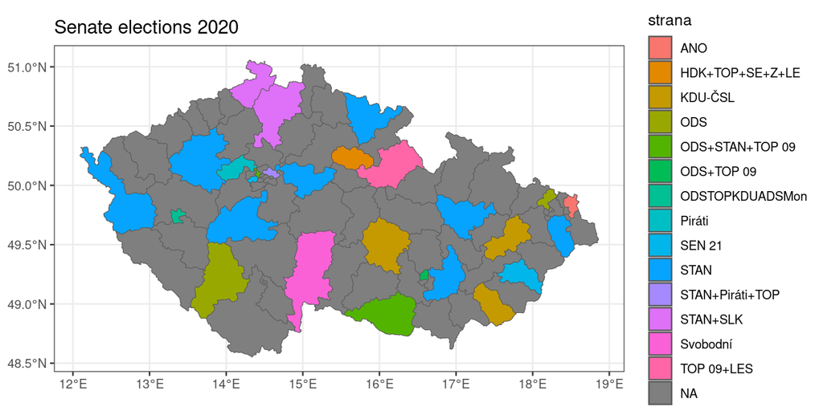

```r
library(RCzechia)
library(ggplot2)
library(dplyr)
library(rvest)

# official result of elections from Czech Statistical Office
vysledky <- "https://www.volby.cz/pls/senat/se1111?xjazyk=CZ&xdatum=20201002&xv=7&xt=2" %>%
  xml2::read_html() %>%  # because rvest::html is deprecated
  html_nodes(xpath = "//*[@id=\"se1111_t1\"]") %>%  # get the table by its xpath
  html_table(fill = T) %>%
  .[[1]] %>%
  dplyr::select(OBVOD = Obvod, strana = `Volebnístrana`) %>%
  # pad OBVOD with zero to 2 places to align to RCzechia data format
  mutate(OBVOD = stringr::str_pad(OBVOD, 2, side = "left", pad = "0"))

podklad <- RCzechia::senat_obvody("low") %>%
  # match by key; left to preserve geometry of off cycle districts (NAs)
  left_join(vysledky, by = "OBVOD")

ggplot() +
  geom_sf(data = RCzechia::republika(), size = .85) + # Czech borders
  geom_sf(data = podklad, aes(fill = strana)) +
  labs(title = "Senate elections 2020") +
  theme_bw()
```